# Identifying covariate traits of trance and possession phenomena in the Ethnographic Atlas using multiple imputation and nested sparse regression

Péter Rácz

14 de April, 2021

## Structure of the SI

The EA dataset is challenging in three ways. (1) Many, correlated, predictors might explain the outcome, (2) Data are structured by cultural and geographic distance, (3) Data are missing.

The analysis attempts to meet the challenge by the (1) Use of shrinkage for predictor selection, (2) Use of a nested model to account for cultural and geographic structure (in a relatively simple way), (3) Use of imputed data in model selection.

Models are fit in R (R Core Team 2019) using Stan (Stan Development Team 2019) and brms (Bürkner 2018). Figures are created using ggplot (Wickham 2016), tidybayes (Kay 2020), and bayesplot (Gabry et al. 2019).

Data come from the Ethnographic Atlas (Murdock 1967) made available in the D-Place database (Kirby et al. 2016) (see helper file).

Analysis was heavily inspired by Kevin Stadler [(*link*)](https://kevinstadler.github.io/blog/bayesian-ordinal-regression-with-random-effects-using-brms/) and Michael Betancourt [(*link*)](https://betanalpha.github.io/assets/case_studies/bayes_sparse_regression.html), as well as by Andrew Gelman’s collection of prior recommendations [(*link*)](https://github.com/stan-dev/stan/wiki/Prior-Choice-Recommendations).

## Structure of the SI

First, we consider the starting predictors. Second, we code the outcome. Third, we consider autocorrelation in the data. Fourth, we consider missing data using imputed datasets. Fifth, we consider variable selection using sparse regression. Sixth, and finally, we refit the best model on the available EA data and perform some additional robustness checks.

## Starting predictor variables

The EA contains values of 94 variables for 1291 societies.

For many of these variables, a large amount of data are missing.

We borrow one of their imputed datasets to help us visualise correlations between our variables. We assume that 74% of the imputations for the missing 25% will be accurate. This means that 94% of the underlying data are accurate.

This is good enough for the figure. We will take data imputation more seriously in the models.

We visualise Spearman correlations between the relevant variables in our imputed dataset. We can see that some of these are strongly correlated. For example, primary class differentiations in a society (EA066) increase with the increase of structure in the larger community (EA033). Different primary subsistence economies (EA042) go together with different levels of local and larger social hierarchical complexity. This makes sense.

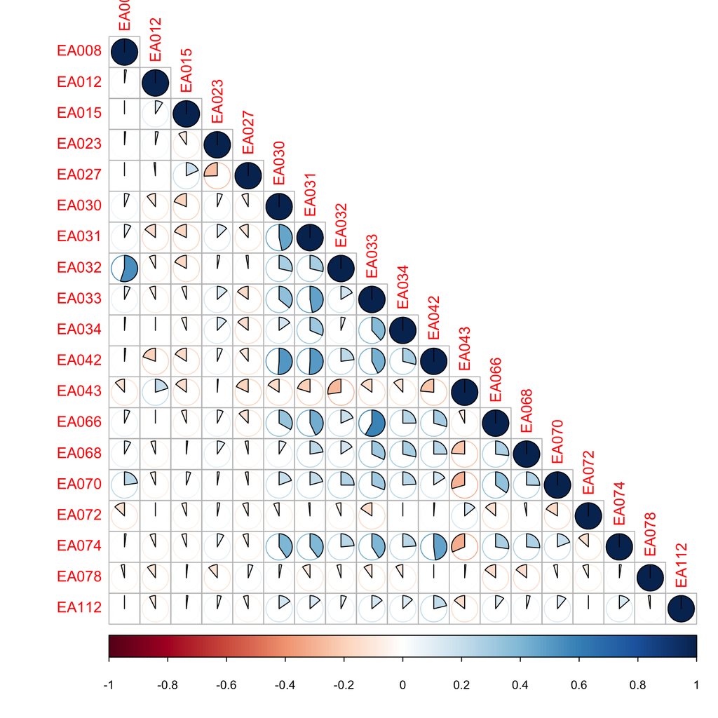

## Outcome variable

Trance and possession states are coded in the Ethnographic Atlas under EA112.

The levels of this categorical variable hint at the difficulty of encoding complex relationship between trance states and possession in human cultures.

For the purposes of this broad-brush analysis, we recognise a number of implicative structures. Societies can be grouped according to whether:

1. *No* trance states are known to occur and *no* belief in possession exists.
2. *Either* trance states are known to occur *or* belief in possession exists.
3. *Both* trance states are known to occur *and* belief in possession exists. *No relationship is stipulated between the two*.
4. *Both* trance states are known to occur *and* belief in possession exists. *Not all* trance states are explained through possession **or** *not all* cases of possession are related to trance.
5. *Both* trance states are known to occur *and* belief in possession exists. *All* trance states are explained through possession **and** *all* cases of possession are related to trance.

Here we stipulated a hierarchy of types of trance and possession beliefs across the societies recorded in the Ethnographic Atlas.

We can put this on a map.

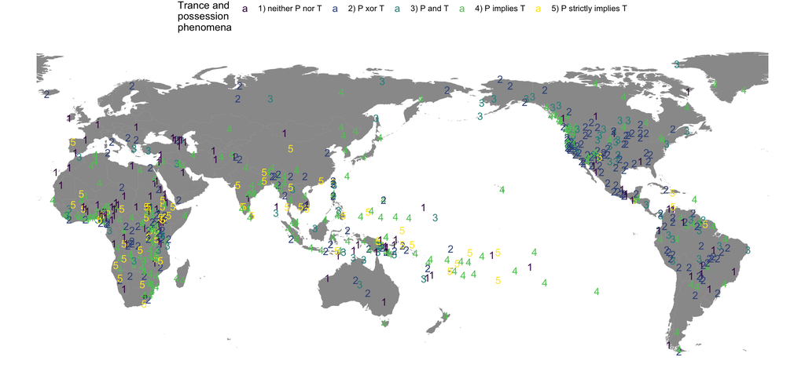

Possession and/or Trance states are posited (2-3) primarily in the Americas in the dataset, whereas strong links are present for the two (4 and especially 5) primarily in Sub-Saharan Africa and Oceania.

Data are missing for 633 societies in the EA data.

## Modelling: coding the outcome

Without making a deep ontological commitment to this hierarchy, we can use it to model the distribution of trance and possession beliefs in the dataset by using an ordered categorical model. This is an extension of the logistic generalised linear regression model which predicts the relative likelihood of one outcome (say, presence of trance states reported in society) over another (say, absence of trance states).

The ordered model assumes that the levels of this hierarchy are ordered from 1 to 5 and predicts the cumulative likelihood of responses in an expanding set of the levels in our hierarchy. It makes a prediction for

- 1 (viz that trance and possession states are categorically absent) vs 2:5 (they are present on some level),
- 1:2 (viz that trance or possession states can be observed but not together) vs 3:5 (they can be observed together)
- 1:3 (viz that trance or possession states can be observed but without a relationship between the two) vs 4:5 (there is a relationship)
- 1:4 (viz that trance or possession states and a relationship between them can be observed but if such a relationship exists it’s not exclusive) vs 5 (the relationship between possession and trance is exclusive)

What we do stipulate is this ordering of the levels. This is justified to some extent by the implicational structure.

## Modelling: accounting for Galton’s problem

The state of the art in accounting for cultural distance between observations relies on phylogenetic comparative methods that use language trees to calculate distances between cultural units and take these distances into account when correcting for autocorrelation. These are difficult to deploy for the EA data, since the 1291 societies in the dataset speak 1211 languages that come from 139 language families.

Following standard practice, we assume a grouping factor for language family and one for geographic-cultural region as defined in the Ethnographic Atlas. These will go to some length in accounting for autocorrelation in cultural behaviour, viz that trance and possession states might be more typical for certain cultural groups or regions.

## Modelling: variable selection

If we want to assume that, among a large set of possibly covariate predictors, only a few have any robust correlation with our outcome, the Bayesian approach is to build this assumption into our model in the form of an informative prior distribution for the predictors. Such sparsity-inducing distributions will allow for variable selection in the vein of the frequentist LASSO method (Tibshirani 1996), except that we introduce sparsity through the distribution rather than by using a penalised maximum likelihood estimator.

We consider three types of prior distributions in our models: a weakly informative Student’s t distribution (which does not push the model towards variable selection), a Laplace distribution (effectively, the Bayesian equivalent of the LASSO method), and the Horseshoe prior, a heavy-tailed Cauchy prior distribution that generally pushes weaker posteriors towards zero (Carvalho, Polson, and Scott 2009), which we use by adjusting the global scale to .5 to favour shrinkage (Piironen and Vehtari 2016).

We use the Widely Applicable Information Criterion (WAIC) and leave-one-out cross-validation for model selection.

## Modelling: missing data

Thompson, Roberts, and Lupyan (2018) published 100 iterations of the imputed EA dataset. These have, on average, 74% accuracy in the imputed values. We draw a random dataset from this set of 100 to fit our model and draw a full set of ten random datasets to refit the model. We walk through these steps below.

## Fitting the model

We draw ten imputed datasets at random from Thompson, Roberts, and Lupyan (2018) and use the **first** of these for model selection.

We fit the model thrice, with a Laplace prior (Fit 1), a Student-t prior (Fit 2), and a Horseshoe prior (Fit 3). We use four mcmc chains with 2000 iterations each.

This process leads us to a best model (Fit 3c) which uses Horseshoe priors and region as grouping factor.

## Robustness checks on imputed data

We take this model and fit it on ten random datasets from the 100 imputed datasets published by Thompson, Roberts, and Lupyan (2018).

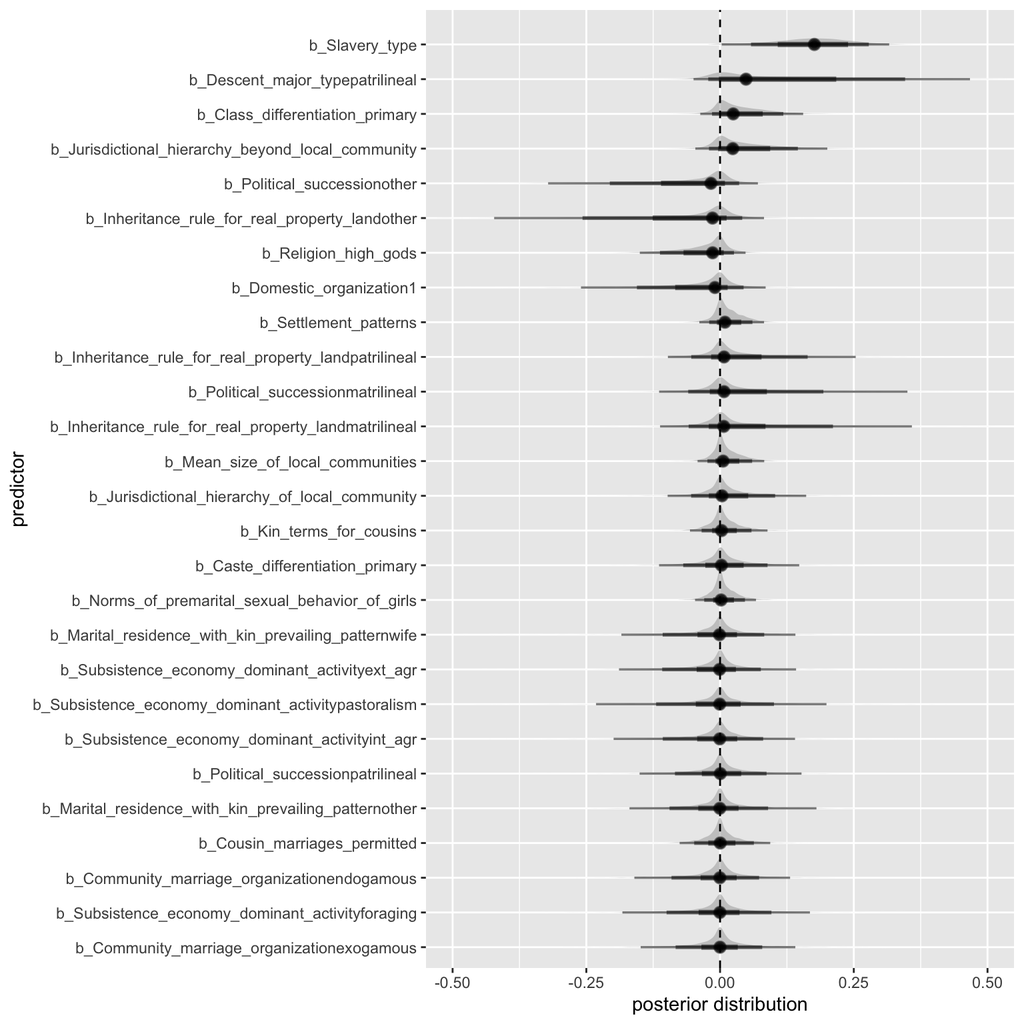

As we see, most predictors have relatively little to contribute in this sparse model.

We can look at the individual posterior distributions of the ten models as well.

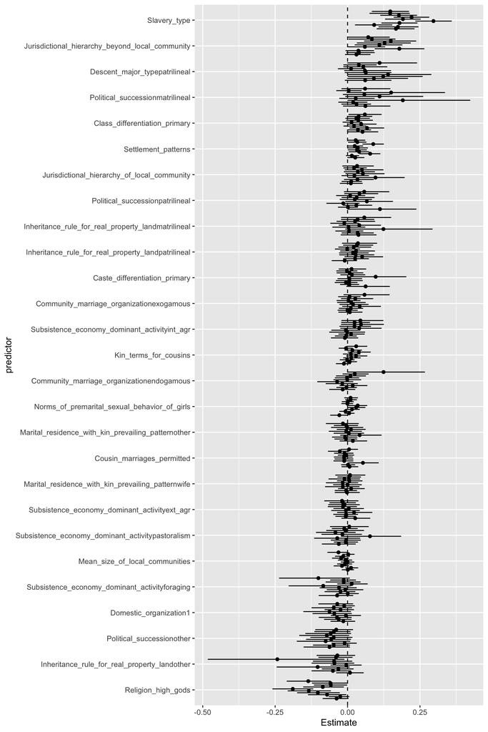

The ten models are identical except for the datasets on which they were fit. The missing values of the EA data were imputed by Thompson, Roberts, and Lupyan (2018) for each imputed dataset. Another way in which we can assess the overall effects across these data is by pooling the draws from the posterior distributions across models. The result can be seen below.

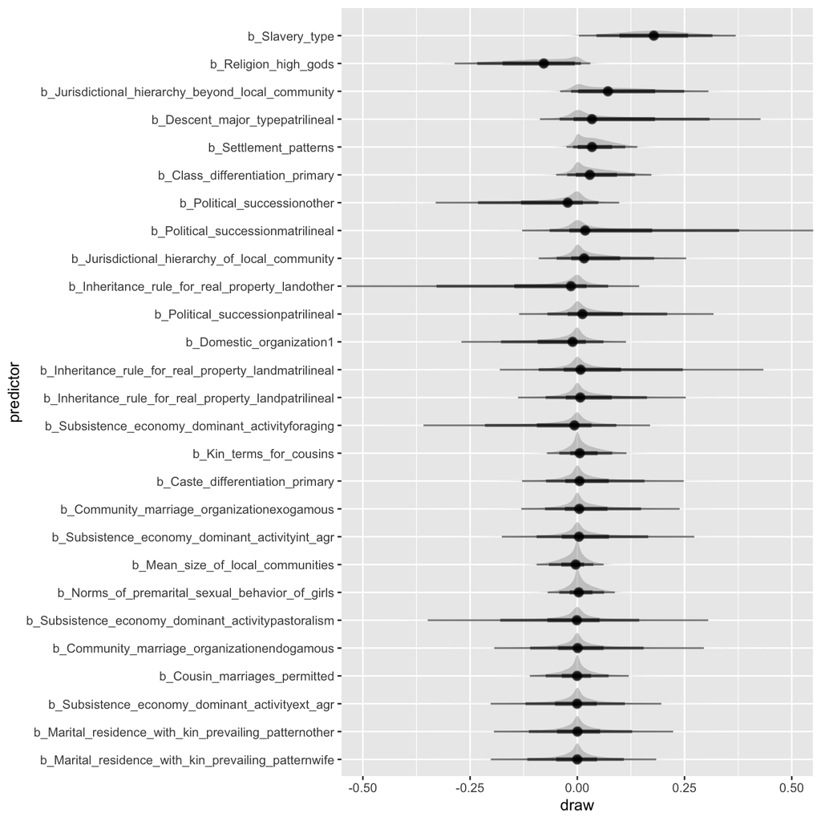

Altogether, across the ten models fit on the ten imputed datasets, most of our predictor variables explain little variation in the outcome.

We pick the top six variables. Note that this is, to some degree, arbitrary. We pick the first five because the the 67% CI of the pooled distribution excludes zero. We pick class differentiation because it sounds interesting.

## Refitting the model on real data

We are now done with variable selection and want to see how well a model with the surviving predictor variables predicts the real data.

We refit the model on the complete observations of the EA (428/1291 societies). We use weakly informative student-t priors for both betas and intercepts.

We check the model using the WAMBS checklist (selectively).

The posterior distributions of the model can be seen below.

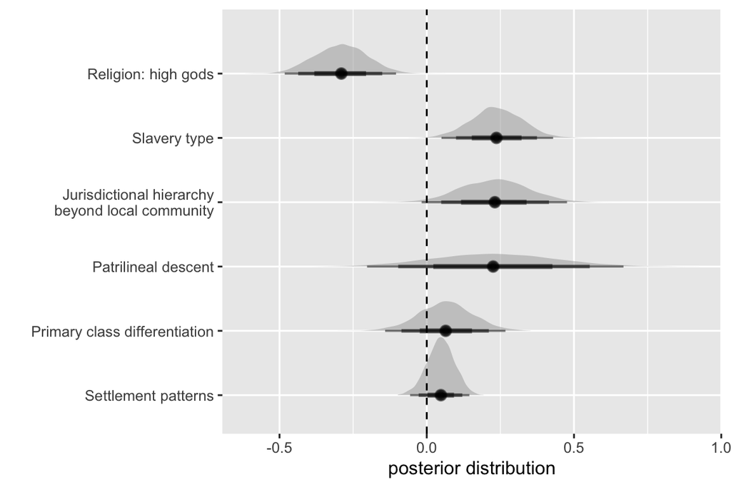

## Robustness checks

We perform two further robustness checks by filtering the dataset.

We filter the data excluding societies speaking languages in the Indo-European family and refit Fit 4 (Fit 5). We also filter the data excluding societies with population size in the highest 5% of natural log population size and refit Fit 4 again (Fit 6).

We draw posteriors for the estimates in these three models and visualise the results below.

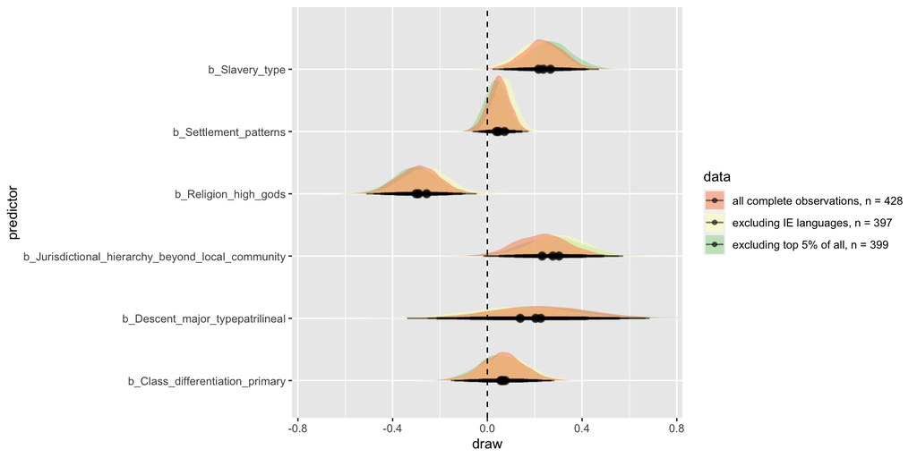

Some effects shrink in the refit models, but the differences are not very large.

## Visualising predictions

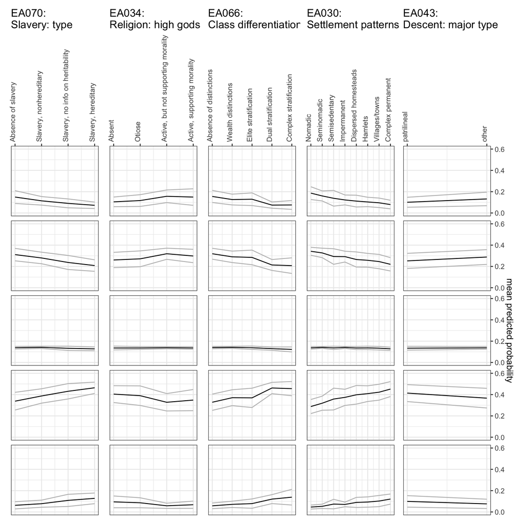

## References

Bürkner, Paul-Christian. 2018. “Advanced Bayesian Multilevel Modeling with the R Package brms.” *The R Journal* 10 (1): 395–411. https://doi.org/10.32614/RJ-2018-017.

Carvalho, Carlos M, Nicholas G Polson, and James G Scott. 2009. “Handling Sparsity via the Horseshoe.” In *Artificial Intelligence and Statistics*, 73–80.

Flom, Peter L, and David L Cassell. 2007. “Stopping Stepwise: Why Stepwise and Similar Selection Methods Are Bad, and What You Should Use.” In *NorthEast SAS Users Group Inc 20th Annual Conference*, 11–14.

Gabry, Jonah, Daniel Simpson, Aki Vehtari, Michael Betancourt, and Andrew Gelman. 2019. “Visualization in Bayesian Workflow.” *J. R. Stat. Soc. A* 182: 389–402. https://doi.org/10.1111/rssa.12378.

Kay, Matthew. 2020. *tidybayes: Tidy Data and Geoms for Bayesian Models*. https://doi.org/10.5281/zenodo.1308151.

Kirby, Kathryn R, Russell D Gray, Simon J Greenhill, Fiona M Jordan, Stephanie Gomes-Ng, Hans-Jörg Bibiko, Damián E Blasi, et al. 2016. “D-PLACE: A Global Database of Cultural, Linguistic and Environmental Diversity.” *PloS One* 11 (7): e0158391.

McElreath, Richard. 2020. *Statistical Rethinking: A Bayesian Course with Examples in r and Stan*. CRC press.

Murdock, George Peter. 1967. “Ethnographic Atlas: A Summary.” *Ethnology* 6 (2): 109–236.

Piironen, Juho, and Aki Vehtari. 2016. “On the Hyperprior Choice for the Global Shrinkage Parameter in the Horseshoe Prior.” *arXiv Preprint arXiv:1610.05559*.

R Core Team. 2019. *R: A Language and Environment for Statistical Computing*. Vienna, Austria: R Foundation for Statistical Computing. https://www.R-project.org/.

Stan Development Team. 2019. “RStan: The R Interface to Stan.” http://mc-stan.org/.

Thompson, Bill, Sean Roberts, and Gary Lupyan. 2018. “Quantifying Semantic Similarity Across Languages.” In *Proceedings of the 40th Annual Conference of the Cognitive Science Society (CogSci 2018)*.

Tibshirani, Robert. 1996. “Regression Shrinkage and Selection via the Lasso.” *Journal of the Royal Statistical Society: Series B (Methodological)* 58 (1): 267–88.

Wickham, Hadley. 2016. *Ggplot2: Elegant Graphics for Data Analysis*. Springer-Verlag New York. https://ggplot2.tidyverse.org.